# Olympic Performance and Economic Indicators

Bekkmo & Guerrero

2026-04-08

## Motivation

### *How well Economic Indicators predict Olympic medal counts across countries in the Summer and Winter Olympics?*

We chose this topic because we are both have international perspectives, and the 2026 Winter Olympics in Italy sparked our interest in understanding why some countries perform better than others in the Olympic Games. This led us to explore whether economic indicators can help predict how many medals a country wins in both the Summer and Winter Olympics.

We were especially interested in looking at whether broader measures of development, such as GDP, population, labor market conditions, and education-related indicators, are associated with Olympic success.

## Data Sources

### Olympic Medal Data and World Bank Indicators

Our project relies on two main data sources. The first is Olympic medal data from the Summer and Winter Games, which we web scraped from Wikipedia medal tables. The second is economic and demographic data from the World Bank Open Data platform, from which we collected a wide range of country-level indicators related to economic development.

The Olympic dataset provides information on medal counts by country, year, and season, while the World Bank dataset adds economic and social context for each country-year observation. Combining these two sources allowed us to study how national characteristics may relate to Olympic performance.

## Data Wrangling and Preparation

### Building the Main Dataset

After collecting the Olympic medal data from Wikipedia and the economic indicators from the World Bank API, we cleaned and combined both sources into one main dataset.

For the Olympic data, we scraped the Wikipedia category pages for both Summer and Winter Olympic medal tables, extracted the yearly page links, and looped through each page to identify the correct medal table. Since the medal table was not always located in the same position on each page, we identified it by checking for key columns such as rank, gold, silver, bronze, and total. We then cleaned country names, removed unnecessary rows such as totals and mixed teams, and added the corresponding year and season.

For the World Bank data, we downloaded multiple economic and demographic indicators from the World Bank’s publicly-available API by country and year, then combined them into one wide dataset. Since there are many indicators, we made a list of potentially relevant indicators to have many variables to select from for our prediction We then left-joined the World Bank data with the Olympic medal data by country and year so that each Olympic observation could be matched with the available country-level indicators.

### Exploring the Variables

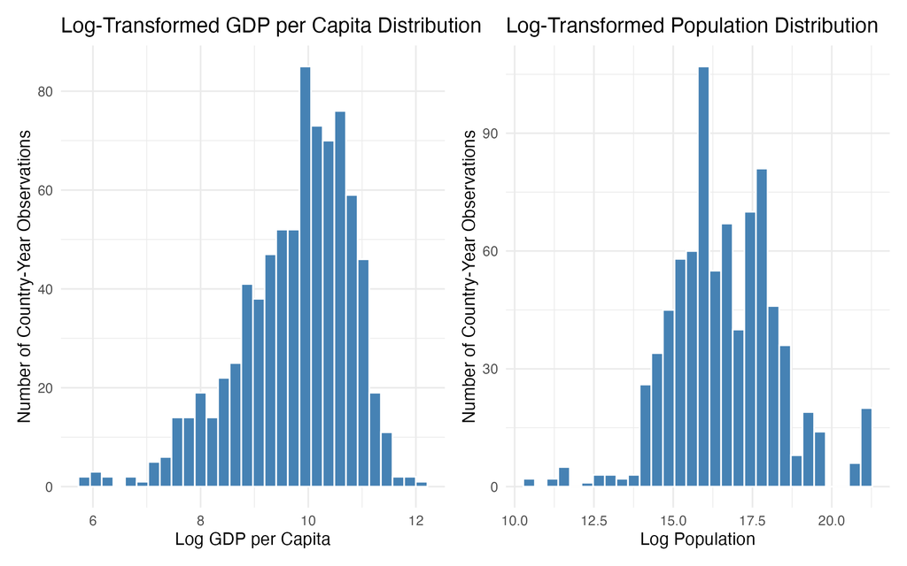

Medal-related variables, however, remained somewhat skewed even after transformation, so we decided not to apply the log transformation for the data visualizations. This is expected, since many countries win very few medals while a small number of countries win many.

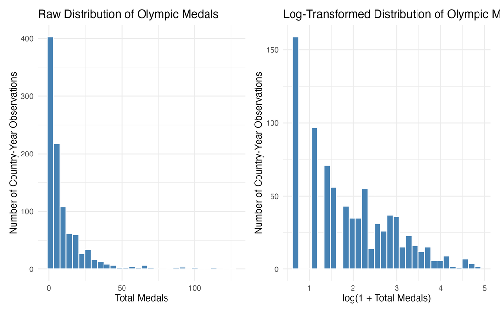

Education spending did not appear to be very skewed and life expectancy appeared to be left-skewed, so we decided to keep these variables as they are without a log transformation.

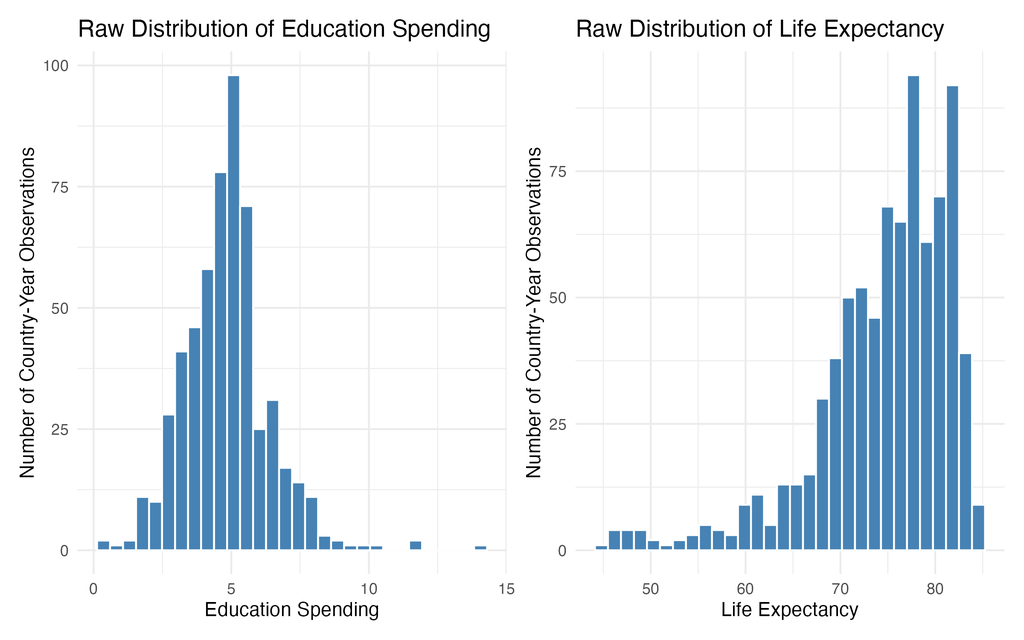

Due to the scope of this stage, we decided to start our focus on these four predictor variables (GDP per capita, population, education spending, and life expectancy) to thoughtfully explore the data and the relationships between these variables and medals.

### Selecting the Most Complete Time Period

Because the World Bank data were incomplete for some countries and earlier years, we also conducted a completeness check by year. We measured the amount of non-missing data available across indicators and identified the period with the strongest overall coverage.

This step allowed us to focus the analysis on the years with the most complete information, creating a cleaner and more reliable dataset for visualization.

## Figures Developed

### Global Distribution of Olympic Medal Totals

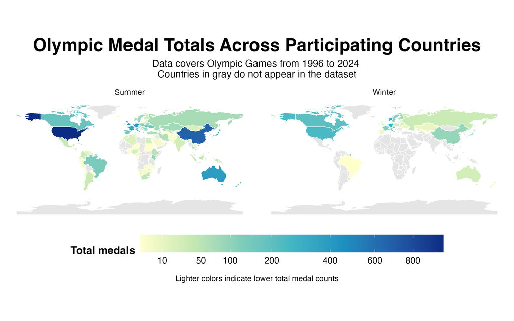

This figure uses a choropleth map to show Olympic medal totals by country for the Summer and Winter Olympics. A map was chosen because the goal is to show geographic patterns in medal distribution across the world, and faceting by season allows an easy comparison between Summer and Winter Games. Color intensity represents total medals, with darker colors indicating higher totals. Because medal totals are highly skewed, a square-root transformation was applied to the color scale so that differences among countries with smaller medal totals are still visible. Gray countries are countries that do not appear in the medal dataset.

### Relationship Between Economic Development and Olympic Success

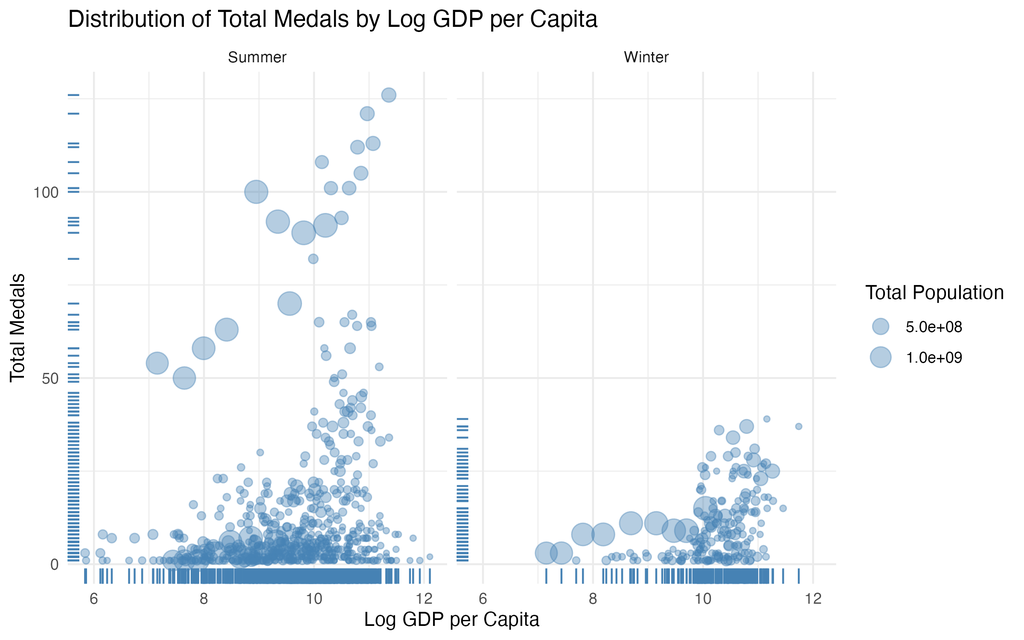

This figure uses a scatter plot with marginal rug plots to examine the relationship between economic development (measured by log GDP per capita) and Olympic success (measured by total medals), with point size representing population. A scatter plot is used because it allows visualization of the association between two continuous variables while also capturing variation across countries and Olympic seasons. Rug plots along the axes provide additional detail on the distribution of observations for both log GDP per capita and total medal counts. Point size is scaled by population to account for differences in country size, which may influence both economic output and Olympic performance. Faceting by season separates Summer and Winter Olympics, allowing for comparison of whether the GDP–medal relationship differs across Olympic contexts.

### Economic Development and Medal Type Distribution

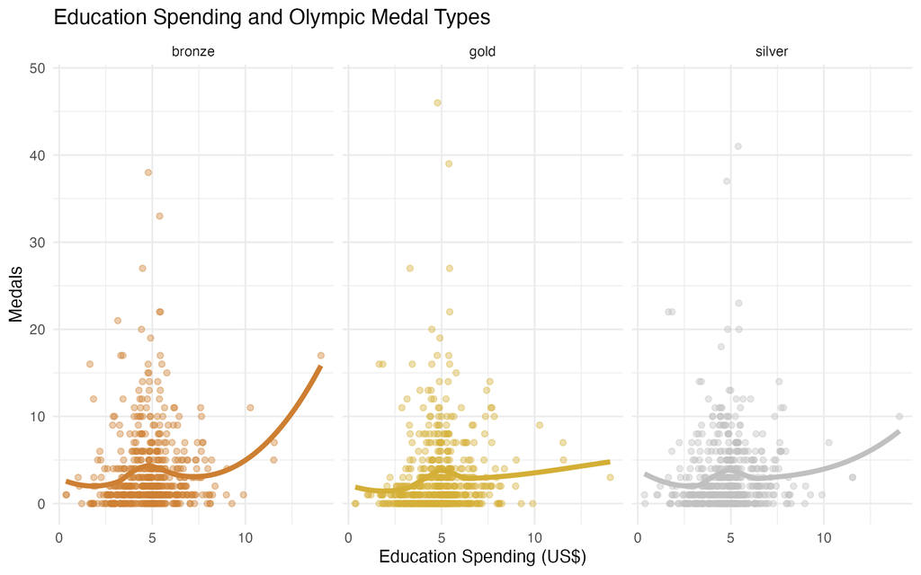

This figure uses a scatter plot with smoothed trend lines to show the relationship between education spending and Olympic medal outcomes by medal type (gold, silver, and bronze). A scatter plot is chosen because it allows visualization of the distribution of country-year observations and the underlying variation in medal counts across different levels of education spending. A LOESS smoothing line is added to highlight the nonlinear relationship between education spending and medal performance without imposing a strict functional form. Faceting by medal type allows for clear comparison of how education spending relates differently to gold, silver, and bronze medal outcomes. Color distinguishes medal types using the standard Olympic color scheme, and the smoothing trends help reveal whether higher education investment is associated with systematically higher medal counts across different medal categories.

### Medal Composition of Top Olympic Countries

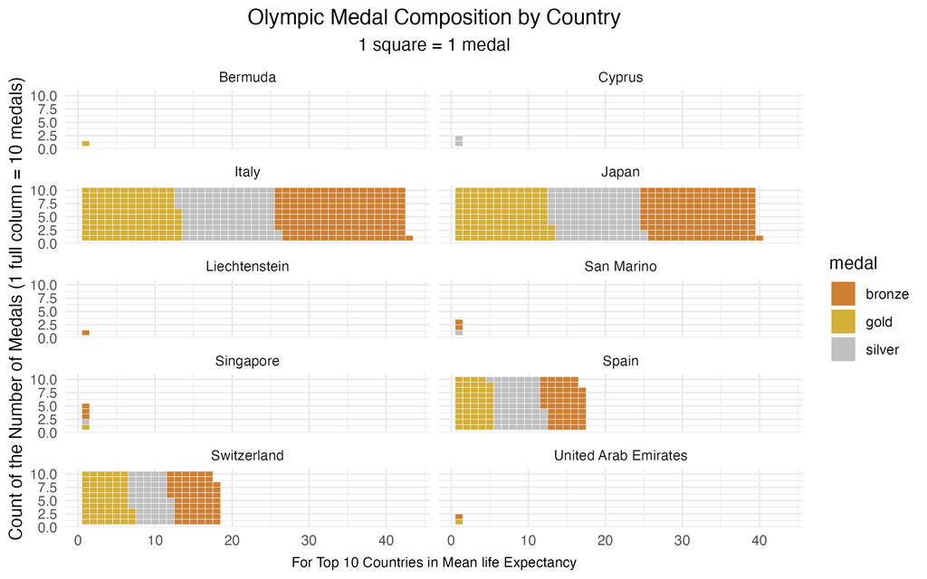

This figure uses a waffle chart to show the composition of Olympic medals (gold, silver, and bronze) for the 10 countries with the highest average life expectancy. A waffle chart is chosen because it provides an intuitive, discrete visualization of categorical parts of a whole, where each square represents one medal and allows direct visual comparison of both total medal counts and medal composition across countries. Faceting by country enables easy comparison of how medal distributions differ across nations with similar levels of life expectancy. Color distinguishes medal types, with gold, silver, and bronze mapped to their standard Olympic color scheme. The figure highlights whether countries with higher life expectancy tend to have not only higher total medal counts but also different compositions of medal types.